# Quiz 4

Rok Bohinc

July 14, 2019

## Question 1

Load the vowel.train and vowel.test data sets:

```r
library(ElemStatLearn)
data(vowel.train)
data(vowel.test)
vowel.train$y <- as.factor(vowel.train$y)
vowel.test$y <- as.factor(vowel.test$y)
set.seed(33833)
```

Set the variable y to be a factor variable in both the training and test set. Then set the seed to 33833. Fit (1) a random forest predictor relating the factor variable y to the remaining variables and (2) a boosted predictor using the “gbm” method. Fit these both with the train() command in the caret package.

```r
library(gbm)
library(caret)
modFitRF <- train(y~ .,data=vowel.train,method="rf",prox=TRUE)
modFitBOOST <- train(y~ .,data=vowel.train,method="gbm",verbose=FALSE)
```

What are the accuracies for the two approaches on the test data set?

```r
predictionsRF <- predict(modFitRF, newdata=vowel.test)
predictionsBOOST <- predict(modFitBOOST, newdata=vowel.test)
```

```r
confusionMatrix(predictionsRF,vowel.test$y)
```

```
## Confusion Matrix and Statistics
##
##           Reference
## Prediction  1  2  3  4  5  6  7  8  9 10 11
##         1  33  1  0  0  0  0  0  0  0  1  0
##         2   9 23  3  0  0  0  0  0  0 17  1
##         3   0 15 32  3  0  0  0  0  0  3  1
##         4   0  0  4 31  3  0  0  0  0  0  2
##         5   0  0  0  0 16  8  9  0  0  0  0
##         6   0  0  3  8 20 26  5  0  0  0  6
##         7   0  0  0  0  3  0 27  6  5  0  3
##         8   0  0  0  0  0  0  0 29  5  0  0
##         9   0  3  0  0  0  0  0  7 24  2 12
##         10  0  0  0  0  0  0  1  0  2 19  0
##         11  0  0  0  0  0  8  0  0  6  0 17
##
## Overall Statistics
##
##                Accuracy : 0.5996
##                  95% CI : (0.5533, 0.6446)
##     No Information Rate : 0.0909
##     P-Value [Acc > NIR] : < 2.2e-16
##
##                   Kappa : 0.5595
##
##  Mcnemar's Test P-Value : NA
##
## Statistics by Class:
##
##                      Class: 1 Class: 2 Class: 3 Class: 4 Class: 5 Class: 6
## Sensitivity           0.78571  0.54762  0.76190  0.73810  0.38095  0.61905
## Specificity           0.99524  0.92857  0.94762  0.97857  0.95952  0.90000
## Pos Pred Value        0.94286  0.43396  0.59259  0.77500  0.48485  0.38235
## Neg Pred Value        0.97892  0.95355  0.97549  0.97393  0.93939  0.95939
## Prevalence            0.09091  0.09091  0.09091  0.09091  0.09091  0.09091
## Detection Rate        0.07143  0.04978  0.06926  0.06710  0.03463  0.05628
## Detection Prevalence  0.07576  0.11472  0.11688  0.08658  0.07143  0.14719
## Balanced Accuracy     0.89048  0.73810  0.85476  0.85833  0.67024  0.75952
##                      Class: 7 Class: 8 Class: 9 Class: 10 Class: 11
## Sensitivity           0.64286  0.69048  0.57143   0.45238   0.40476
## Specificity           0.95952  0.98810  0.94286   0.99286   0.96667
## Pos Pred Value        0.61364  0.85294  0.50000   0.86364   0.54839
## Neg Pred Value        0.96411  0.96963  0.95652   0.94773   0.94200
## Prevalence            0.09091  0.09091  0.09091   0.09091   0.09091
## Detection Rate        0.05844  0.06277  0.05195   0.04113   0.03680
## Detection Prevalence  0.09524  0.07359  0.10390   0.04762   0.06710
## Balanced Accuracy     0.80119  0.83929  0.75714   0.72262   0.68571
```

```r
confusionMatrix(predictionsBOOST,vowel.test$y)
```

```
## Confusion Matrix and Statistics
##
##           Reference
## Prediction  1  2  3  4  5  6  7  8  9 10 11
##         1  28  0  0  0  0  0  0  0  0  2  0
##         2  10 21  1  0  0  0  1  0  0 13  0
##         3   2  9 11  3  0  0  0  0  0  0  0
##         4   0  0  7 23  3  0  1  0  0  0  0
##         5   0  0  0  2 17  6  1  0  0  0  0
##         6   0  2 18 13 10 28  0  0  3  0 10
##         7   0  0  0  0  8  1 37  9  5  0 10
##         8   0  0  0  0  0  0  2 28  8  0  0
##         9   0  6  0  0  0  0  0  5 26  5 18
##         10  2  0  0  0  0  0  0  0  0 22  0
##         11  0  4  5  1  4  7  0  0  0  0  4
##
## Overall Statistics
##
##                Accuracy : 0.5303
##                  95% CI : (0.4836, 0.5766)
##     No Information Rate : 0.0909
##     P-Value [Acc > NIR] : < 2.2e-16
##
##                   Kappa : 0.4833
##
##  Mcnemar's Test P-Value : NA
##
## Statistics by Class:
##
##                      Class: 1 Class: 2 Class: 3 Class: 4 Class: 5 Class: 6
## Sensitivity           0.66667  0.50000  0.26190  0.54762  0.40476  0.66667
## Specificity           0.99524  0.94048  0.96667  0.97381  0.97857  0.86667
## Pos Pred Value        0.93333  0.45652  0.44000  0.67647  0.65385  0.33333
## Neg Pred Value        0.96759  0.94952  0.92906  0.95561  0.94266  0.96296
## Prevalence            0.09091  0.09091  0.09091  0.09091  0.09091  0.09091
## Detection Rate        0.06061  0.04545  0.02381  0.04978  0.03680  0.06061
## Detection Prevalence  0.06494  0.09957  0.05411  0.07359  0.05628  0.18182
## Balanced Accuracy     0.83095  0.72024  0.61429  0.76071  0.69167  0.76667
##                      Class: 7 Class: 8 Class: 9 Class: 10 Class: 11
## Sensitivity           0.88095  0.66667  0.61905   0.52381  0.095238
## Specificity           0.92143  0.97619  0.91905   0.99524  0.950000
## Pos Pred Value        0.52857  0.73684  0.43333   0.91667  0.160000
## Neg Pred Value        0.98724  0.96698  0.96020   0.95434  0.913043
## Prevalence            0.09091  0.09091  0.09091   0.09091  0.090909
## Detection Rate        0.08009  0.06061  0.05628   0.04762  0.008658
## Detection Prevalence  0.15152  0.08225  0.12987   0.05195  0.054113
## Balanced Accuracy     0.90119  0.82143  0.76905   0.75952  0.522619
```

What is the accuracy among the test set samples where the two methods agree?

```r
table(predictionsRF, predictionsBOOST)
```

```
##              predictionsBOOST
## predictionsRF  1  2  3  4  5  6  7  8  9 10 11
##            1  28  2  1  0  0  0  0  0  0  3  1
##            2   1 38  4  0  0  1  0  0  5  2  2
##            3   1  4 20  5  0 15  1  0  0  2  6
##            4   0  0  0 28  0  8  0  0  2  0  2
##            5   0  0  0  0 18  2 10  2  0  0  1
##            6   0  0  0  1  7 48  9  0  0  0  3
##            7   0  1  0  0  1  0 41  0  1  0  0
##            8   0  0  0  0  0  0  3 31  0  0  0
##            9   0  0  0  0  0  0  1  5 41  1  0
##            10  0  1  0  0  0  0  1  0  4 16  0
##            11  0  0  0  0  0 10  4  0  7  0 10
```

```r
sum(diag(table(predictionsRF, predictionsBOOST)))/sum(table(predictionsRF, predictionsBOOST))
```

```
## [1] 0.6904762
```

The answer is closest to: * RF Accuracy = 0.6082, GBM Accuracy = 0.5152, Agreement Accuracy = 0.6361

## Question 2

### Training and Testing

```r
library(caret)
library(gbm)
set.seed(3433)
library(AppliedPredictiveModeling)
data(AlzheimerDisease)
adData = data.frame(diagnosis,predictors)
inTrain = createDataPartition(adData$diagnosis, p = 3/4)[[1]]
training = adData[ inTrain,]
testing = adData[-inTrain,]
```

Set the seed to 62433 and predict diagnosis with all the other variables using a random forest (“rf”), boosted trees (“gbm”) and linear discriminant analysis (“lda”) model. Stack the predictions together using random forests (“rf”). What is the resulting accuracy on the test set? Is it better or worse than each of the individual predictions?

Fit with different models

```r
set.seed(62433)
modFitRF <- train(diagnosis~ .,data=training,method="rf",prox=TRUE)
modFitBOOST <- train(diagnosis~ .,data=training,method="gbm",verbose=FALSE)
modFitLDA = train(diagnosis ~ .,data=training,method="lda") # linear discriminative analysis
```

```r
predRF <- predict(modFitRF,testing);
predBOOST <- predict(modFitBOOST,testing);
predLDA <- predict(modFitLDA,testing);
```

Combine

```r
predDF <- data.frame(predRF,predBOOST,predLDA,diagnosis=testing$diagnosis)
combModFit <- train(diagnosis ~.,method="rf",data=predDF)
combPred <- predict(combModFit,predDF)
```

```r
cmRF <- confusionMatrix(predRF, testing$diagnosis)
cmBOOST <- confusionMatrix(predBOOST, testing$diagnosis)
cmLDA <- confusionMatrix(predLDA, testing$diagnosis)
cmCOMB <- confusionMatrix(combPred, testing$diagnosis)

data.frame(RF = cmRF$overall['Accuracy'],BOOST = cmBOOST$overall['Accuracy'], LDA = cmLDA$overall['Accuracy'], COMB = cmCOMB$overall['Accuracy'])
```

```
##                RF     BOOST       LDA      COMB
## Accuracy 0.902439 0.8902439 0.9146341 0.9268293
```

- I have no idea which answer to pick

## Question 3

```r
set.seed(3523)
library(AppliedPredictiveModeling)
data(concrete)
inTrain = createDataPartition(concrete$CompressiveStrength, p = 3/4)[[1]]
training = concrete[ inTrain,]
testing = concrete[-inTrain,]
```

Set the seed to 233 and fit a lasso model to predict Compressive Strength. Which variable is the last coefficient to be set to zero as the penalty increases? (Hint: it may be useful to look up ?plot.enet).

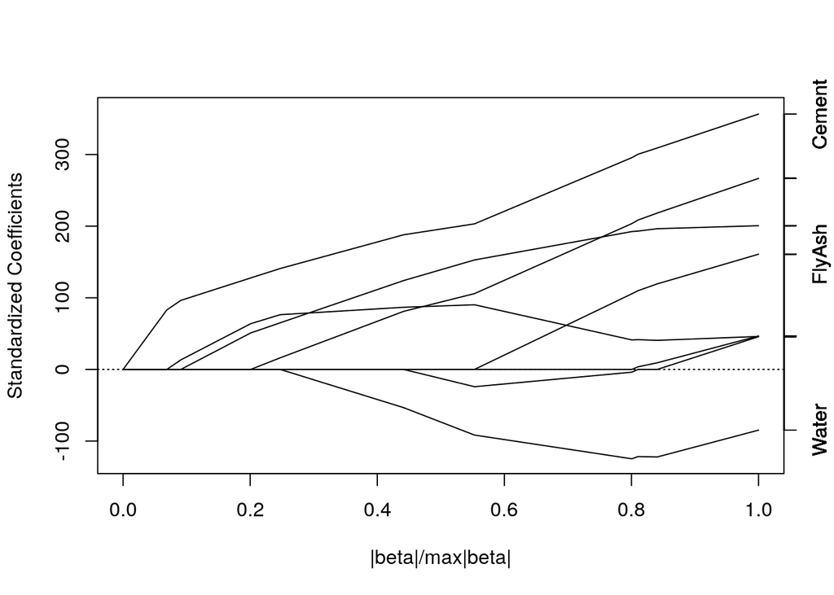

```r
set.seed(233)
modFit <- train(CompressiveStrength~ .,data=training,method="lasso")
plot(modFit$finalModel)
```

```r
modFit$finalModel
```

```
##
## Call:
## elasticnet::enet(x = as.matrix(x), y = y, lambda = 0)
## Cp statistics of the Lasso fit
## Cp: 1323.434 1001.612  924.941  609.923  507.643  196.693  101.092   13.040   12.138   10.166    9.000
## DF: 1 2 3 4 5 6 7 8 8 8 9
## Sequence of  moves:
##      Cement Superplasticizer Age BlastFurnaceSlag Water FineAggregate
## Var       1                5   8                2     4             7
## Step      1                2   3                4     5             6
##      FlyAsh CoarseAggregate FineAggregate FineAggregate
## Var       3               6            -7             7 11
## Step      7               8             9            10 11
```

## Question 4

```r
library(lubridate) # For year() function below

setwd("/home/rok/Edjucation/2019.3.28. Data_Science-Specialization/Practical Machine Learning/Week 4/Scripts")
if (!file.exists("data")){
    dir.create("data")
}
fileURL <- "https://d396qusza40orc.cloudfront.net/predmachlearn/gaData.csv"

# download data and metadata

download.file(fileURL, destfile = "./data/Ohio.csv", method = "curl")

dat = read.csv("./data/Ohio.csv")
training = dat[year(dat$date) < 2012,]
testing = dat[(year(dat$date)) > 2011,]
tstrain = ts(training$visitsTumblr)
```

Fit a model using the bats() function in the forecast package to the training time series. Then forecast this model for the remaining time points. For how many of the testing points is the true value within the 95% prediction interval bounds?

```r
library(forecast)
ets1 <- bats(y = tstrain)
fcast <- forecast(ets1,h = length(testing$visitsTumblr))
LOW <- fcast$lower[,2]
HIGH <- fcast$upper[,2]
sum(testing$visitsTumblr < HIGH & LOW < testing$visitsTumblr)/length(testing$visitsTumblr)
```

```
## [1] 0.9617021
```

```r
#lines(ts(testing$visitsTumblr),col="red")
```

## Question 5

```r
set.seed(3523)
library(AppliedPredictiveModeling)
data(concrete)
inTrain = createDataPartition(concrete$CompressiveStrength, p = 3/4)[[1]]
training = concrete[ inTrain,]
testing = concrete[-inTrain,]
```

Set the seed to 325 and fit a support vector machine using the e1071 package to predict Compressive Strength using the default settings. Predict on the testing set. What is the RMSE?